# Risk Factor Analysis

## Outcome Variable

**Outcome Variable:** whz

## Predictor Variables

**Intervention Variable:** exclfeed3

**Adjustment Set:**

- arm
- sex
- brthmon
- W_mage
- meducyrs
- feducyrs
- hhwealth_quart
- hfoodsec
- W_mhtcm
- W_mwtkg
- W_mbmi
- vagbrth
- W_gagebrth
- W_birthwt
- W_birthlen
- W_nrooms
- W_nchldlt5
- month
- W_parity
- impfloor
- impsan
- safeh20
- delta_W_mage
- delta_meducyrs
- delta_feducyrs
- delta_hhwealth_quart
- delta_hfoodsec
- delta_W_mhtcm
- delta_W_mwtkg
- delta_W_mbmi
- delta_vagbrth
- delta_W_gagebrth
- delta_W_birthwt
- delta_W_birthlen
- delta_W_nrooms
- delta_W_nchldlt5
- delta_month
- delta_W_parity
- delta_impfloor
- delta_impsan
- delta_safeh20

## Stratifying Variables

The analysis was stratified on these variable(s):

- agecat
- studyid
- country

## Data Summary

| agecat | studyid | country | exclfeed3 | n_cell | n | outcome_variable |
| --- | --- | --- | --- | --- | --- | --- |
| Birth | CMC-V-BCS-2002 | INDIA | 1 | 4 | 4 | whz |
| Birth | CMC-V-BCS-2002 | INDIA | 0 | 0 | 4 | whz |
| Birth | EE | PAKISTAN | 1 | 22 | 22 | whz |
| Birth | EE | PAKISTAN | 0 | 0 | 22 | whz |
| Birth | GMS-Nepal | NEPAL | 1 | 352 | 422 | whz |
| Birth | GMS-Nepal | NEPAL | 0 | 70 | 422 | whz |
| Birth | IRC | INDIA | 1 | 0 | 9 | whz |
| Birth | IRC | INDIA | 0 | 9 | 9 | whz |
| Birth | JiVitA-3 | BANGLADESH | 1 | 9636 | 10634 | whz |
| Birth | JiVitA-3 | BANGLADESH | 0 | 998 | 10634 | whz |
| Birth | JiVitA-4 | BANGLADESH | 1 | 89 | 97 | whz |
| Birth | JiVitA-4 | BANGLADESH | 0 | 8 | 97 | whz |
| Birth | Keneba | GAMBIA | 1 | 1133 | 1282 | whz |
| Birth | Keneba | GAMBIA | 0 | 149 | 1282 | whz |
| Birth | MAL-ED | BANGLADESH | 1 | 130 | 202 | whz |
| Birth | MAL-ED | BANGLADESH | 0 | 72 | 202 | whz |
| Birth | MAL-ED | BRAZIL | 1 | 11 | 55 | whz |
| Birth | MAL-ED | BRAZIL | 0 | 44 | 55 | whz |
| Birth | MAL-ED | INDIA | 1 | 22 | 39 | whz |
| Birth | MAL-ED | INDIA | 0 | 17 | 39 | whz |
| Birth | MAL-ED | NEPAL | 1 | 8 | 25 | whz |
| Birth | MAL-ED | NEPAL | 0 | 17 | 25 | whz |
| Birth | MAL-ED | PERU | 1 | 47 | 218 | whz |
| Birth | MAL-ED | PERU | 0 | 171 | 218 | whz |
| Birth | MAL-ED | SOUTH AFRICA | 1 | 12 | 99 | whz |
| Birth | MAL-ED | SOUTH AFRICA | 0 | 87 | 99 | whz |
| Birth | MAL-ED | TANZANIA, UNITED REPUBLIC OF | 1 | 15 | 95 | whz |
| Birth | MAL-ED | TANZANIA, UNITED REPUBLIC OF | 0 | 80 | 95 | whz |
| Birth | PROVIDE | BANGLADESH | 1 | 381 | 532 | whz |
| Birth | PROVIDE | BANGLADESH | 0 | 151 | 532 | whz |

[output cut: 64 more lines]

The following strata were considered:

- agecat: 24 months, studyid: CMC-V-BCS-2002, country: INDIA
- agecat: 24 months, studyid: EE, country: PAKISTAN
- agecat: 24 months, studyid: GMS-Nepal, country: NEPAL
- agecat: 24 months, studyid: IRC, country: INDIA
- agecat: 24 months, studyid: JiVitA-3, country: BANGLADESH
- agecat: 24 months, studyid: JiVitA-4, country: BANGLADESH
- agecat: 24 months, studyid: Keneba, country: GAMBIA
- agecat: 24 months, studyid: MAL-ED, country: BANGLADESH
- agecat: 24 months, studyid: MAL-ED, country: BRAZIL
- agecat: 24 months, studyid: MAL-ED, country: INDIA
- agecat: 24 months, studyid: MAL-ED, country: NEPAL
- agecat: 24 months, studyid: MAL-ED, country: PERU
- agecat: 24 months, studyid: MAL-ED, country: SOUTH AFRICA
- agecat: 24 months, studyid: MAL-ED, country: TANZANIA, UNITED REPUBLIC OF
- agecat: 24 months, studyid: PROVIDE, country: BANGLADESH
- agecat: 6 months, studyid: CMC-V-BCS-2002, country: INDIA
- agecat: 6 months, studyid: EE, country: PAKISTAN
- agecat: 6 months, studyid: GMS-Nepal, country: NEPAL
- agecat: 6 months, studyid: IRC, country: INDIA
- agecat: 6 months, studyid: JiVitA-3, country: BANGLADESH
- agecat: 6 months, studyid: JiVitA-4, country: BANGLADESH
- agecat: 6 months, studyid: Keneba, country: GAMBIA
- agecat: 6 months, studyid: MAL-ED, country: BANGLADESH
- agecat: 6 months, studyid: MAL-ED, country: BRAZIL
- agecat: 6 months, studyid: MAL-ED, country: INDIA
- agecat: 6 months, studyid: MAL-ED, country: NEPAL
- agecat: 6 months, studyid: MAL-ED, country: PERU
- agecat: 6 months, studyid: MAL-ED, country: SOUTH AFRICA
- agecat: 6 months, studyid: MAL-ED, country: TANZANIA, UNITED REPUBLIC OF
- agecat: 6 months, studyid: PROVIDE, country: BANGLADESH
- agecat: 6 months, studyid: SAS-CompFeed, country: INDIA
- agecat: Birth, studyid: CMC-V-BCS-2002, country: INDIA
- agecat: Birth, studyid: EE, country: PAKISTAN
- agecat: Birth, studyid: GMS-Nepal, country: NEPAL
- agecat: Birth, studyid: IRC, country: INDIA
- agecat: Birth, studyid: JiVitA-3, country: BANGLADESH
- agecat: Birth, studyid: JiVitA-4, country: BANGLADESH
- agecat: Birth, studyid: Keneba, country: GAMBIA
- agecat: Birth, studyid: MAL-ED, country: BANGLADESH
- agecat: Birth, studyid: MAL-ED, country: BRAZIL
- agecat: Birth, studyid: MAL-ED, country: INDIA
- agecat: Birth, studyid: MAL-ED, country: NEPAL
- agecat: Birth, studyid: MAL-ED, country: PERU
- agecat: Birth, studyid: MAL-ED, country: SOUTH AFRICA
- agecat: Birth, studyid: MAL-ED, country: TANZANIA, UNITED REPUBLIC OF
- agecat: Birth, studyid: PROVIDE, country: BANGLADESH
- agecat: Birth, studyid: SAS-CompFeed, country: INDIA

### Dropped Strata

Some strata were dropped due to rare outcomes:

- agecat: Birth, studyid: CMC-V-BCS-2002, country: INDIA
- agecat: Birth, studyid: EE, country: PAKISTAN
- agecat: Birth, studyid: IRC, country: INDIA
- agecat: 6 months, studyid: CMC-V-BCS-2002, country: INDIA
- agecat: 6 months, studyid: EE, country: PAKISTAN
- agecat: 6 months, studyid: IRC, country: INDIA
- agecat: 24 months, studyid: CMC-V-BCS-2002, country: INDIA
- agecat: 24 months, studyid: EE, country: PAKISTAN
- agecat: 24 months, studyid: IRC, country: INDIA

## Methods Detail

We’re interested in the causal parameters $E[Y_a]$ for all values of $a \in \mathcal{A}$. These parameters represent the mean outcome if, possibly contrary to fact, we intervened to set all units to have $A=a$. Under the randomization and positivity assumptions, these are identified by the statistical parameters $\psi_a=E_W[E_{Y|A,W}(Y|A=a,W)]$. In addition, we’re interested in the mean of $Y$, $E[Y]$ under no intervention (the observed mean). We will estimate these parameters by using SuperLearner to fit the relevant likelihood factors – $E_{Y|A,W}(Y|A=a,W)$ and $p(A=a|W)$, and then updating our likelihood fit using a joint TMLE.

For unadjusted analyses ($W=\{\}$), initial likelihoods were estimated using Lrnr_glm to estimate the simple $E(Y|A)$ and Lrnr_mean to estimate $p(A)$. For adjusted analyses, a small library containing Lrnr_glmnet, Lrnr_xgboost, and Lrnr_mean was used.

Having estimated these parameters, we will then use the delta method to estimate relative risks and attributable risks relative to a prespecified baseline level of $A$.

# Results Detail

## Results Plots

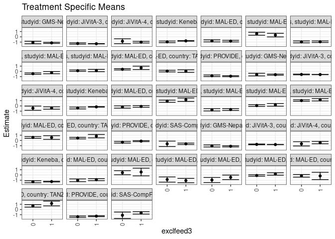

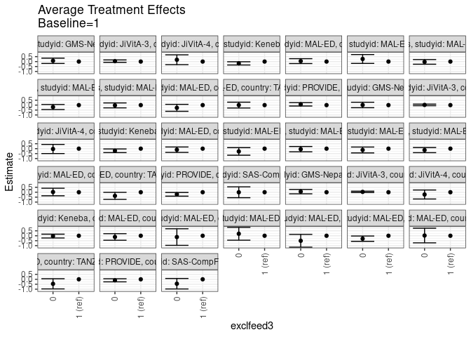

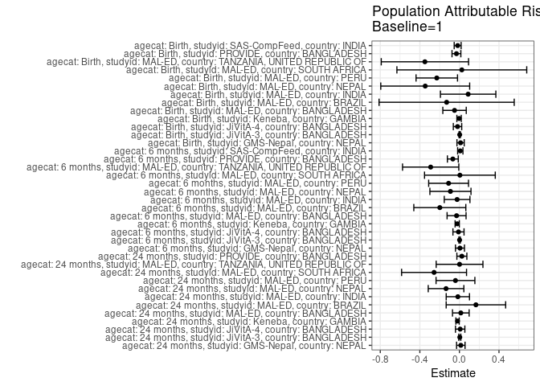

## Results Table

### Parameter: TSM

| agecat | studyid | country | intervention_level | baseline_level | estimate | ci_lower | ci_upper |
| --- | --- | --- | --- | --- | --- | --- | --- |
| Birth | GMS-Nepal | NEPAL | 1 | NA | -1.1110199 | -1.2292147 | -0.9928252 |
| Birth | GMS-Nepal | NEPAL | 0 | NA | -1.0511687 | -1.2524146 | -0.8499229 |
| Birth | JiVitA-3 | BANGLADESH | 1 | NA | -0.7828989 | -0.8061395 | -0.7596582 |
| Birth | JiVitA-3 | BANGLADESH | 0 | NA | -0.7505089 | -0.8167856 | -0.6842321 |
| Birth | JiVitA-4 | BANGLADESH | 1 | NA | -0.4156180 | -0.6383645 | -0.1928714 |
| Birth | JiVitA-4 | BANGLADESH | 0 | NA | -0.6475000 | -1.0569566 | -0.2380434 |
| Birth | Keneba | GAMBIA | 1 | NA | -1.2595711 | -1.3276131 | -1.1915290 |
| Birth | Keneba | GAMBIA | 0 | NA | -1.2925377 | -1.4819411 | -1.1031343 |
| Birth | MAL-ED | BANGLADESH | 1 | NA | -0.8918578 | -1.0821201 | -0.7015955 |
| Birth | MAL-ED | BANGLADESH | 0 | NA | -1.0139954 | -1.2732529 | -0.7547380 |
| Birth | MAL-ED | BRAZIL | 1 | NA | 0.5607444 | -0.1788534 | 1.3003423 |
| Birth | MAL-ED | BRAZIL | 0 | NA | 0.4307055 | 0.0428913 | 0.8185198 |
| Birth | MAL-ED | INDIA | 1 | NA | -1.0662286 | -1.4749215 | -0.6575357 |
| Birth | MAL-ED | INDIA | 0 | NA | -0.8641765 | -1.3543670 | -0.3739860 |
| Birth | MAL-ED | NEPAL | 1 | NA | -0.4487500 | -0.8783289 | -0.0191711 |
| Birth | MAL-ED | NEPAL | 0 | NA | -0.9570588 | -1.4394884 | -0.4746293 |
| Birth | MAL-ED | PERU | 1 | NA | 0.1951152 | -0.0304819 | 0.4207122 |
| Birth | MAL-ED | PERU | 0 | NA | -0.1011930 | -0.2444498 | 0.0420638 |
| Birth | MAL-ED | SOUTH AFRICA | 1 | NA | -0.1833332 | -0.8780023 | 0.5113360 |
| Birth | MAL-ED | SOUTH AFRICA | 0 | NA | -0.1608815 | -0.4036115 | 0.0818485 |
| Birth | MAL-ED | TANZANIA, UNITED REPUBLIC OF | 1 | NA | 1.1485686 | 0.6922949 | 1.6048424 |
| Birth | MAL-ED | TANZANIA, UNITED REPUBLIC OF | 0 | NA | 0.6906436 | 0.4579255 | 0.9233618 |
| Birth | PROVIDE | BANGLADESH | 1 | NA | -1.2684117 | -1.3561755 | -1.1806480 |
| Birth | PROVIDE | BANGLADESH | 0 | NA | -1.3682470 | -1.5058425 | -1.2306515 |
| Birth | SAS-CompFeed | INDIA | 1 | NA | -0.6419787 | -0.8661092 | -0.4178481 |
| Birth | SAS-CompFeed | INDIA | 0 | NA | -1.0901281 | -1.7027393 | -0.4775170 |
| 6 months | GMS-Nepal | NEPAL | 1 | NA | -0.6255616 | -0.7356558 | -0.5154674 |
| 6 months | GMS-Nepal | NEPAL | 0 | NA | -0.6123158 | -0.8651580 | -0.3594735 |
| 6 months | JiVitA-3 | BANGLADESH | 1 | NA | -0.6058560 | -0.6314152 | -0.5802969 |
| 6 months | JiVitA-3 | BANGLADESH | 0 | NA | -0.5863746 | -0.6638240 | -0.5089253 |
| 6 months | JiVitA-4 | BANGLADESH | 1 | NA | -0.4016803 | -0.6298870 | -0.1734737 |
| 6 months | JiVitA-4 | BANGLADESH | 0 | NA | -0.4344356 | -0.8363241 | -0.0325472 |
| 6 months | Keneba | GAMBIA | 1 | NA | -0.1833658 | -0.2417375 | -0.1249940 |
| 6 months | Keneba | GAMBIA | 0 | NA | -0.3971782 | -0.5736995 | -0.2206569 |
| 6 months | MAL-ED | BANGLADESH | 1 | NA | -0.1018005 | -0.2678461 | 0.0642451 |
| 6 months | MAL-ED | BANGLADESH | 0 | NA | -0.2086757 | -0.4276755 | 0.0103241 |
| 6 months | MAL-ED | BRAZIL | 1 | NA | 1.1734578 | 0.8498696 | 1.4970459 |
| 6 months | MAL-ED | BRAZIL | 0 | NA | 0.8946309 | 0.6846752 | 1.1045865 |
| 6 months | MAL-ED | INDIA | 1 | NA | -0.6953293 | -0.8612511 | -0.5294075 |
| 6 months | MAL-ED | INDIA | 0 | NA | -0.7457904 | -0.9548472 | -0.5367336 |
| 6 months | MAL-ED | NEPAL | 1 | NA | 0.1948237 | -0.0570974 | 0.4467449 |
| 6 months | MAL-ED | NEPAL | 0 | NA | 0.0607298 | -0.1010703 | 0.2225300 |
| 6 months | MAL-ED | PERU | 1 | NA | 1.1607093 | 0.9464651 | 1.3749535 |
| 6 months | MAL-ED | PERU | 0 | NA | 1.0155847 | 0.8698754 | 1.1612940 |
| 6 months | MAL-ED | SOUTH AFRICA | 1 | NA | 0.5513861 | 0.2047890 | 0.8979832 |
| 6 months | MAL-ED | SOUTH AFRICA | 0 | NA | 0.5716981 | 0.4087462 | 0.7346500 |
| 6 months | MAL-ED | TANZANIA, UNITED REPUBLIC OF | 1 | NA | 0.8163293 | 0.4944307 | 1.1382279 |
| 6 months | MAL-ED | TANZANIA, UNITED REPUBLIC OF | 0 | NA | 0.4465876 | 0.2942270 | 0.5989481 |
| 6 months | PROVIDE | BANGLADESH | 1 | NA | -0.1325832 | -0.2265785 | -0.0385880 |
| 6 months | PROVIDE | BANGLADESH | 0 | NA | -0.3455776 | -0.5086795 | -0.1824757 |
| 6 months | SAS-CompFeed | INDIA | 1 | NA | -0.6438016 | -0.7819173 | -0.5056859 |
| 6 months | SAS-CompFeed | INDIA | 0 | NA | -0.6500492 | -1.1672739 | -0.1328245 |
| 24 months | GMS-Nepal | NEPAL | 1 | NA | -1.1538411 | -1.2665064 | -1.0411758 |
| 24 months | GMS-Nepal | NEPAL | 0 | NA | -1.0743395 | -1.3181351 | -0.8305440 |
| 24 months | JiVitA-3 | BANGLADESH | 1 | NA | -1.3149233 | -1.3468147 | -1.2830319 |
| 24 months | JiVitA-3 | BANGLADESH | 0 | NA | -1.2714335 | -1.3907240 | -1.1521430 |
| 24 months | JiVitA-4 | BANGLADESH | 1 | NA | -1.0173056 | -1.1802456 | -0.8543656 |
| 24 months | JiVitA-4 | BANGLADESH | 0 | NA | -0.8333365 | -1.2989743 | -0.3676987 |
| 24 months | Keneba | GAMBIA | 1 | NA | -0.7742045 | -0.8284523 | -0.7199566 |
| 24 months | Keneba | GAMBIA | 0 | NA | -0.9568444 | -1.1110559 | -0.8026328 |
| 24 months | MAL-ED | BANGLADESH | 1 | NA | -0.8220249 | -0.9783182 | -0.6657316 |
| 24 months | MAL-ED | BANGLADESH | 0 | NA | -0.7763468 | -0.9673163 | -0.5853773 |
| 24 months | MAL-ED | BRAZIL | 1 | NA | 0.3312767 | -0.0177902 | 0.6803437 |
| 24 months | MAL-ED | BRAZIL | 0 | NA | 0.5934861 | 0.3100056 | 0.8769666 |
| 24 months | MAL-ED | INDIA | 1 | NA | -0.9358969 | -1.0883268 | -0.7834669 |
| 24 months | MAL-ED | INDIA | 0 | NA | -0.9688889 | -1.1512380 | -0.7865398 |
| 24 months | MAL-ED | NEPAL | 1 | NA | -0.2439905 | -0.4577211 | -0.0302599 |
| 24 months | MAL-ED | NEPAL | 0 | NA | -0.4369530 | -0.5775077 | -0.2963983 |
| 24 months | MAL-ED | PERU | 1 | NA | 0.1574832 | -0.0569060 | 0.3718723 |
| 24 months | MAL-ED | PERU | 0 | NA | 0.1293550 | -0.0087223 | 0.2674323 |
| 24 months | MAL-ED | SOUTH AFRICA | 1 | NA | 0.6682685 | 0.3433255 | 0.9932116 |
| 24 months | MAL-ED | SOUTH AFRICA | 0 | NA | 0.3936658 | 0.2628229 | 0.5245088 |
| 24 months | MAL-ED | TANZANIA, UNITED REPUBLIC OF | 1 | NA | 0.0480654 | -0.1971689 | 0.2932997 |
| 24 months | MAL-ED | TANZANIA, UNITED REPUBLIC OF | 0 | NA | 0.0507717 | -0.1100052 | 0.2115487 |
| 24 months | PROVIDE | BANGLADESH | 1 | NA | -0.9177857 | -1.0133700 | -0.8222014 |
| 24 months | PROVIDE | BANGLADESH | 0 | NA | -0.8381815 | -0.9870463 | -0.6893166 |

### Parameter: E(Y)

| agecat | studyid | country | intervention_level | baseline_level | estimate | ci_lower | ci_upper |
| --- | --- | --- | --- | --- | --- | --- | --- |
| Birth | GMS-Nepal | NEPAL | NA | NA | -1.0991706 | -1.2073693 | -0.9909719 |
| Birth | JiVitA-3 | BANGLADESH | NA | NA | -0.7798636 | -0.8022140 | -0.7575133 |
| Birth | JiVitA-4 | BANGLADESH | NA | NA | -0.4347423 | -0.6441144 | -0.2253701 |
| Birth | Keneba | GAMBIA | NA | NA | -1.2629563 | -1.3291505 | -1.1967622 |
| Birth | MAL-ED | BANGLADESH | NA | NA | -0.9411386 | -1.0895370 | -0.7927402 |
| Birth | MAL-ED | BRAZIL | NA | NA | 0.4316364 | 0.0969688 | 0.7663039 |
| Birth | MAL-ED | INDIA | NA | NA | -0.9779487 | -1.2664810 | -0.6894164 |
| Birth | MAL-ED | NEPAL | NA | NA | -0.7944000 | -1.1625222 | -0.4262778 |
| Birth | MAL-ED | PERU | NA | NA | -0.0335321 | -0.1564905 | 0.0894263 |
| Birth | MAL-ED | SOUTH AFRICA | NA | NA | -0.1588889 | -0.3845288 | 0.0667510 |
| Birth | MAL-ED | TANZANIA, UNITED REPUBLIC OF | NA | NA | 0.7996842 | 0.5874808 | 1.0118876 |
| Birth | PROVIDE | BANGLADESH | NA | NA | -1.2984586 | -1.3752758 | -1.2216415 |
| Birth | SAS-CompFeed | INDIA | NA | NA | -0.6596308 | -0.9005716 | -0.4186900 |
| 6 months | GMS-Nepal | NEPAL | NA | NA | -0.6198791 | -0.7206518 | -0.5191063 |
| 6 months | JiVitA-3 | BANGLADESH | NA | NA | -0.6040977 | -0.6286619 | -0.5795335 |
| 6 months | JiVitA-4 | BANGLADESH | NA | NA | -0.4110227 | -0.6122701 | -0.2097753 |
| 6 months | Keneba | GAMBIA | NA | NA | -0.2057183 | -0.2614359 | -0.1500006 |
| 6 months | MAL-ED | BANGLADESH | NA | NA | -0.1304936 | -0.2625419 | 0.0015547 |
| 6 months | MAL-ED | BRAZIL | NA | NA | 0.9754144 | 0.7990651 | 1.1517638 |
| 6 months | MAL-ED | INDIA | NA | NA | -0.7185992 | -0.8491469 | -0.5880515 |
| 6 months | MAL-ED | NEPAL | NA | NA | 0.1041483 | -0.0311352 | 0.2394318 |
| 6 months | MAL-ED | PERU | NA | NA | 1.0514136 | 0.9289176 | 1.1739096 |
| 6 months | MAL-ED | SOUTH AFRICA | NA | NA | 0.5564071 | 0.4055220 | 0.7072922 |
| 6 months | MAL-ED | TANZANIA, UNITED REPUBLIC OF | NA | NA | 0.5257626 | 0.3871543 | 0.6643709 |
| 6 months | PROVIDE | BANGLADESH | NA | NA | -0.1990907 | -0.2817968 | -0.1163845 |
| 6 months | SAS-CompFeed | INDIA | NA | NA | -0.6348861 | -0.7630511 | -0.5067211 |
| 24 months | GMS-Nepal | NEPAL | NA | NA | -1.1396441 | -1.2416403 | -1.0376479 |
| 24 months | JiVitA-3 | BANGLADESH | NA | NA | -1.3109518 | -1.3423299 | -1.2795737 |
| 24 months | JiVitA-4 | BANGLADESH | NA | NA | -1.0096000 | -1.1619164 | -0.8572836 |
| 24 months | Keneba | GAMBIA | NA | NA | -0.7930925 | -0.8442611 | -0.7419240 |
| 24 months | MAL-ED | BANGLADESH | NA | NA | -0.8076829 | -0.9296166 | -0.6857493 |
| 24 months | MAL-ED | BRAZIL | NA | NA | 0.4981140 | 0.2760418 | 0.7201863 |
| 24 months | MAL-ED | INDIA | NA | NA | -0.9516832 | -1.0703961 | -0.8329703 |
| 24 months | MAL-ED | NEPAL | NA | NA | -0.3790455 | -0.4958857 | -0.2622052 |
| 24 months | MAL-ED | PERU | NA | NA | 0.1176052 | -0.0015211 | 0.2367315 |
| 24 months | MAL-ED | SOUTH AFRICA | NA | NA | 0.4120797 | 0.2900939 | 0.5340654 |
| 24 months | MAL-ED | TANZANIA, UNITED REPUBLIC OF | NA | NA | 0.0495743 | -0.0857535 | 0.1849021 |
| 24 months | PROVIDE | BANGLADESH | NA | NA | -0.8928670 | -0.9755153 | -0.8102187 |

### Parameter: ATE

| agecat | studyid | country | intervention_level | baseline_level | estimate | ci_lower | ci_upper |
| --- | --- | --- | --- | --- | --- | --- | --- |
| Birth | GMS-Nepal | NEPAL | 1 | 1 | 0.0000000 | 0.0000000 | 0.0000000 |
| Birth | GMS-Nepal | NEPAL | 0 | 1 | 0.0598512 | -0.1598455 | 0.2795479 |
| Birth | JiVitA-3 | BANGLADESH | 1 | 1 | 0.0000000 | 0.0000000 | 0.0000000 |
| Birth | JiVitA-3 | BANGLADESH | 0 | 1 | 0.0323900 | -0.0362898 | 0.1010699 |
| Birth | JiVitA-4 | BANGLADESH | 1 | 1 | 0.0000000 | 0.0000000 | 0.0000000 |
| Birth | JiVitA-4 | BANGLADESH | 0 | 1 | -0.2318820 | -0.6871466 | 0.2233826 |
| Birth | Keneba | GAMBIA | 1 | 1 | 0.0000000 | 0.0000000 | 0.0000000 |
| Birth | Keneba | GAMBIA | 0 | 1 | -0.0329667 | -0.2268442 | 0.1609109 |
| Birth | MAL-ED | BANGLADESH | 1 | 1 | 0.0000000 | 0.0000000 | 0.0000000 |
| Birth | MAL-ED | BANGLADESH | 0 | 1 | -0.1221377 | -0.4531033 | 0.2088279 |
| Birth | MAL-ED | BRAZIL | 1 | 1 | 0.0000000 | 0.0000000 | 0.0000000 |
| Birth | MAL-ED | BRAZIL | 0 | 1 | -0.1300389 | -0.9692834 | 0.7092056 |
| Birth | MAL-ED | INDIA | 1 | 1 | 0.0000000 | 0.0000000 | 0.0000000 |
| Birth | MAL-ED | INDIA | 0 | 1 | 0.2020521 | -0.4467985 | 0.8509028 |
| Birth | MAL-ED | NEPAL | 1 | 1 | 0.0000000 | 0.0000000 | 0.0000000 |
| Birth | MAL-ED | NEPAL | 0 | 1 | -0.5083088 | -1.1542781 | 0.1376604 |
| Birth | MAL-ED | PERU | 1 | 1 | 0.0000000 | 0.0000000 | 0.0000000 |
| Birth | MAL-ED | PERU | 0 | 1 | -0.2963082 | -0.5645381 | -0.0280782 |
| Birth | MAL-ED | SOUTH AFRICA | 1 | 1 | 0.0000000 | 0.0000000 | 0.0000000 |
| Birth | MAL-ED | SOUTH AFRICA | 0 | 1 | 0.0224517 | -0.7178310 | 0.7627343 |
| Birth | MAL-ED | TANZANIA, UNITED REPUBLIC OF | 1 | 1 | 0.0000000 | 0.0000000 | 0.0000000 |
| Birth | MAL-ED | TANZANIA, UNITED REPUBLIC OF | 0 | 1 | -0.4579250 | -0.9735836 | 0.0577336 |
| Birth | PROVIDE | BANGLADESH | 1 | 1 | 0.0000000 | 0.0000000 | 0.0000000 |
| Birth | PROVIDE | BANGLADESH | 0 | 1 | -0.0998353 | -0.2562810 | 0.0566104 |
| Birth | SAS-CompFeed | INDIA | 1 | 1 | 0.0000000 | 0.0000000 | 0.0000000 |
| Birth | SAS-CompFeed | INDIA | 0 | 1 | -0.4481495 | -0.9783681 | 0.0820692 |
| 6 months | GMS-Nepal | NEPAL | 1 | 1 | 0.0000000 | 0.0000000 | 0.0000000 |
| 6 months | GMS-Nepal | NEPAL | 0 | 1 | 0.0132459 | -0.2623739 | 0.2888656 |
| 6 months | JiVitA-3 | BANGLADESH | 1 | 1 | 0.0000000 | 0.0000000 | 0.0000000 |
| 6 months | JiVitA-3 | BANGLADESH | 0 | 1 | 0.0194814 | -0.0609326 | 0.0998955 |
| 6 months | JiVitA-4 | BANGLADESH | 1 | 1 | 0.0000000 | 0.0000000 | 0.0000000 |
| 6 months | JiVitA-4 | BANGLADESH | 0 | 1 | -0.0327553 | -0.4939697 | 0.4284591 |
| 6 months | Keneba | GAMBIA | 1 | 1 | 0.0000000 | 0.0000000 | 0.0000000 |
| 6 months | Keneba | GAMBIA | 0 | 1 | -0.2138124 | -0.3990602 | -0.0285646 |
| 6 months | MAL-ED | BANGLADESH | 1 | 1 | 0.0000000 | 0.0000000 | 0.0000000 |
| 6 months | MAL-ED | BANGLADESH | 0 | 1 | -0.1068752 | -0.3822566 | 0.1685062 |
| 6 months | MAL-ED | BRAZIL | 1 | 1 | 0.0000000 | 0.0000000 | 0.0000000 |
| 6 months | MAL-ED | BRAZIL | 0 | 1 | -0.2788269 | -0.6629256 | 0.1052718 |
| 6 months | MAL-ED | INDIA | 1 | 1 | 0.0000000 | 0.0000000 | 0.0000000 |
| 6 months | MAL-ED | INDIA | 0 | 1 | -0.0504611 | -0.3196698 | 0.2187475 |
| 6 months | MAL-ED | NEPAL | 1 | 1 | 0.0000000 | 0.0000000 | 0.0000000 |
| 6 months | MAL-ED | NEPAL | 0 | 1 | -0.1340939 | -0.4308567 | 0.1626689 |
| 6 months | MAL-ED | PERU | 1 | 1 | 0.0000000 | 0.0000000 | 0.0000000 |
| 6 months | MAL-ED | PERU | 0 | 1 | -0.1451246 | -0.4046797 | 0.1144305 |
| 6 months | MAL-ED | SOUTH AFRICA | 1 | 1 | 0.0000000 | 0.0000000 | 0.0000000 |
| 6 months | MAL-ED | SOUTH AFRICA | 0 | 1 | 0.0203121 | -0.3629884 | 0.4036125 |
| 6 months | MAL-ED | TANZANIA, UNITED REPUBLIC OF | 1 | 1 | 0.0000000 | 0.0000000 | 0.0000000 |
| 6 months | MAL-ED | TANZANIA, UNITED REPUBLIC OF | 0 | 1 | -0.3697418 | -0.7265328 | -0.0129508 |
| 6 months | PROVIDE | BANGLADESH | 1 | 1 | 0.0000000 | 0.0000000 | 0.0000000 |
| 6 months | PROVIDE | BANGLADESH | 0 | 1 | -0.2129944 | -0.3997963 | -0.0261924 |
| 6 months | SAS-CompFeed | INDIA | 1 | 1 | 0.0000000 | 0.0000000 | 0.0000000 |
| 6 months | SAS-CompFeed | INDIA | 0 | 1 | -0.0062476 | -0.5560776 | 0.5435824 |
| 24 months | GMS-Nepal | NEPAL | 1 | 1 | 0.0000000 | 0.0000000 | 0.0000000 |
| 24 months | GMS-Nepal | NEPAL | 0 | 1 | 0.0795016 | -0.1892098 | 0.3482130 |
| 24 months | JiVitA-3 | BANGLADESH | 1 | 1 | 0.0000000 | 0.0000000 | 0.0000000 |
| 24 months | JiVitA-3 | BANGLADESH | 0 | 1 | 0.0434898 | -0.0783343 | 0.1653138 |
| 24 months | JiVitA-4 | BANGLADESH | 1 | 1 | 0.0000000 | 0.0000000 | 0.0000000 |
| 24 months | JiVitA-4 | BANGLADESH | 0 | 1 | 0.1839691 | -0.3134144 | 0.6813526 |
| 24 months | Keneba | GAMBIA | 1 | 1 | 0.0000000 | 0.0000000 | 0.0000000 |
| 24 months | Keneba | GAMBIA | 0 | 1 | -0.1826399 | -0.3461112 | -0.0191686 |
| 24 months | MAL-ED | BANGLADESH | 1 | 1 | 0.0000000 | 0.0000000 | 0.0000000 |
| 24 months | MAL-ED | BANGLADESH | 0 | 1 | 0.0456781 | -0.2007100 | 0.2920662 |
| 24 months | MAL-ED | BRAZIL | 1 | 1 | 0.0000000 | 0.0000000 | 0.0000000 |
| 24 months | MAL-ED | BRAZIL | 0 | 1 | 0.2622094 | -0.1852724 | 0.7096911 |
| 24 months | MAL-ED | INDIA | 1 | 1 | 0.0000000 | 0.0000000 | 0.0000000 |
| 24 months | MAL-ED | INDIA | 0 | 1 | -0.0329920 | -0.2690436 | 0.2030595 |
| 24 months | MAL-ED | NEPAL | 1 | 1 | 0.0000000 | 0.0000000 | 0.0000000 |
| 24 months | MAL-ED | NEPAL | 0 | 1 | -0.1929625 | -0.4492171 | 0.0632921 |
| 24 months | MAL-ED | PERU | 1 | 1 | 0.0000000 | 0.0000000 | 0.0000000 |
| 24 months | MAL-ED | PERU | 0 | 1 | -0.0281282 | -0.2779445 | 0.2216881 |
| 24 months | MAL-ED | SOUTH AFRICA | 1 | 1 | 0.0000000 | 0.0000000 | 0.0000000 |
| 24 months | MAL-ED | SOUTH AFRICA | 0 | 1 | -0.2746027 | -0.6275753 | 0.0783700 |
| 24 months | MAL-ED | TANZANIA, UNITED REPUBLIC OF | 1 | 1 | 0.0000000 | 0.0000000 | 0.0000000 |
| 24 months | MAL-ED | TANZANIA, UNITED REPUBLIC OF | 0 | 1 | 0.0027063 | -0.2915740 | 0.2969867 |
| 24 months | PROVIDE | BANGLADESH | 1 | 1 | 0.0000000 | 0.0000000 | 0.0000000 |
| 24 months | PROVIDE | BANGLADESH | 0 | 1 | 0.0796042 | -0.0917645 | 0.2509730 |

### Parameter: PAR

| agecat | studyid | country | intervention_level | baseline_level | estimate | ci_lower | ci_upper |
| --- | --- | --- | --- | --- | --- | --- | --- |
| Birth | GMS-Nepal | NEPAL | 1 | NA | 0.0118493 | -0.0247358 | 0.0484344 |
| Birth | JiVitA-3 | BANGLADESH | 1 | NA | 0.0030352 | -0.0034565 | 0.0095269 |
| Birth | JiVitA-4 | BANGLADESH | 1 | NA | -0.0191243 | -0.0615870 | 0.0233385 |
| Birth | Keneba | GAMBIA | 1 | NA | -0.0033853 | -0.0255471 | 0.0187766 |
| Birth | MAL-ED | BANGLADESH | 1 | NA | -0.0492808 | -0.1677460 | 0.0691844 |
| Birth | MAL-ED | BRAZIL | 1 | NA | -0.1291081 | -0.8122523 | 0.5540361 |
| Birth | MAL-ED | INDIA | 1 | NA | 0.0882799 | -0.1918561 | 0.3684159 |
| Birth | MAL-ED | NEPAL | 1 | NA | -0.3456500 | -0.7950359 | 0.1037359 |
| Birth | MAL-ED | PERU | 1 | NA | -0.2286473 | -0.4382741 | -0.0190205 |
| Birth | MAL-ED | SOUTH AFRICA | 1 | NA | 0.0244443 | -0.6318767 | 0.6807653 |
| Birth | MAL-ED | TANZANIA, UNITED REPUBLIC OF | 1 | NA | -0.3488844 | -0.7902732 | 0.0925044 |
| Birth | PROVIDE | BANGLADESH | 1 | NA | -0.0300469 | -0.0747781 | 0.0146843 |
| Birth | SAS-CompFeed | INDIA | 1 | NA | -0.0176521 | -0.0527130 | 0.0174088 |
| 6 months | GMS-Nepal | NEPAL | 1 | NA | 0.0056826 | -0.0397840 | 0.0511492 |
| 6 months | JiVitA-3 | BANGLADESH | 1 | NA | 0.0017583 | -0.0052336 | 0.0087502 |
| 6 months | JiVitA-4 | BANGLADESH | 1 | NA | -0.0093424 | -0.0654461 | 0.0467613 |
| 6 months | Keneba | GAMBIA | 1 | NA | -0.0223525 | -0.0436314 | -0.0010736 |
| 6 months | MAL-ED | BANGLADESH | 1 | NA | -0.0286930 | -0.1246511 | 0.0672650 |
| 6 months | MAL-ED | BRAZIL | 1 | NA | -0.1980433 | -0.4609826 | 0.0648960 |
| 6 months | MAL-ED | INDIA | 1 | NA | -0.0232699 | -0.1531129 | 0.1065731 |
| 6 months | MAL-ED | NEPAL | 1 | NA | -0.0906754 | -0.2984460 | 0.1170952 |
| 6 months | MAL-ED | PERU | 1 | NA | -0.1092957 | -0.3106572 | 0.0920658 |
| 6 months | MAL-ED | SOUTH AFRICA | 1 | NA | 0.0050210 | -0.3525901 | 0.3626321 |
| 6 months | MAL-ED | TANZANIA, UNITED REPUBLIC OF | 1 | NA | -0.2905667 | -0.5748972 | -0.0062363 |
| 6 months | PROVIDE | BANGLADESH | 1 | NA | -0.0665074 | -0.1214639 | -0.0115509 |
| 6 months | SAS-CompFeed | INDIA | 1 | NA | 0.0089155 | -0.0178262 | 0.0356572 |
| 24 months | GMS-Nepal | NEPAL | 1 | NA | 0.0141970 | -0.0285790 | 0.0569730 |
| 24 months | JiVitA-3 | BANGLADESH | 1 | NA | 0.0039715 | -0.0063237 | 0.0142668 |
| 24 months | JiVitA-4 | BANGLADESH | 1 | NA | 0.0077056 | -0.0396798 | 0.0550911 |
| 24 months | Keneba | GAMBIA | 1 | NA | -0.0188881 | -0.0356673 | -0.0021088 |
| 24 months | MAL-ED | BANGLADESH | 1 | NA | 0.0143420 | -0.0697923 | 0.0984763 |
| 24 months | MAL-ED | BRAZIL | 1 | NA | 0.1668373 | -0.1338254 | 0.4675000 |
| 24 months | MAL-ED | INDIA | 1 | NA | -0.0157863 | -0.1334555 | 0.1018829 |
| 24 months | MAL-ED | NEPAL | 1 | NA | -0.1350550 | -0.3151747 | 0.0450648 |
| 24 months | MAL-ED | PERU | 1 | NA | -0.0398779 | -0.2361435 | 0.1563876 |
| 24 months | MAL-ED | SOUTH AFRICA | 1 | NA | -0.2561888 | -0.5844458 | 0.0720682 |
| 24 months | MAL-ED | TANZANIA, UNITED REPUBLIC OF | 1 | NA | 0.0015089 | -0.2349014 | 0.2379192 |
| 24 months | PROVIDE | BANGLADESH | 1 | NA | 0.0249187 | -0.0255656 | 0.0754030 |